# R Project

Armand Leopold - Florent Bacque - Romain Chateau

14 novembre 2016

## Loading packages

```r
require(pROC)
require(class)
require(randomForest)
require(e1071)
require(tree)
require(CORElearn)
require(dplyr)
require(ggplot2)
require(ggthemes)
```

## Loading dataset

```r
dataset <- read.csv("bank.csv", header=TRUE, sep = ";")
dataset$contact <- NULL
names(dataset)
```

```
##  [1] "age"       "job"       "marital"   "education" "default"
##  [6] "balance"   "housing"   "loan"      "day"       "month"
## [11] "duration"  "campaign"  "pdays"     "previous"  "poutcome"
## [16] "y"
```

```r
str(dataset)
```

```
## 'data.frame':    4521 obs. of  16 variables:
##  $ age      : int  30 33 35 30 59 35 36 39 41 43 ...
##  $ job      : Factor w/ 12 levels "admin.","blue-collar",..: 11 8 5 5 2 5 7 10 3 8 ...
##  $ marital  : Factor w/ 3 levels "divorced","married",..: 2 2 3 2 2 3 2 2 2 2 ...
##  $ education: Factor w/ 4 levels "primary","secondary",..: 1 2 3 3 2 3 3 2 3 1 ...
##  $ default  : Factor w/ 2 levels "no","yes": 1 1 1 1 1 1 1 1 1 1 ...
##  $ balance  : int  1787 4789 1350 1476 0 747 307 147 221 -88 ...
##  $ housing  : Factor w/ 2 levels "no","yes": 1 2 2 2 2 1 2 2 2 2 ...
##  $ loan     : Factor w/ 2 levels "no","yes": 1 2 1 2 1 1 1 1 1 2 ...
##  $ day      : int  19 11 16 3 5 23 14 6 14 17 ...
##  $ month    : Factor w/ 12 levels "apr","aug","dec",..: 11 9 1 7 9 4 9 9 9 1 ...
##  $ duration : int  79 220 185 199 226 141 341 151 57 313 ...
##  $ campaign : int  1 1 1 4 1 2 1 2 2 1 ...
##  $ pdays    : int  -1 339 330 -1 -1 176 330 -1 -1 147 ...
##  $ previous : int  0 4 1 0 0 3 2 0 0 2 ...
##  $ poutcome : Factor w/ 4 levels "failure","other",..: 4 1 1 4 4 1 2 4 4 1 ...
##  $ y        : Factor w/ 2 levels "no","yes": 1 1 1 1 1 1 1 1 1 1 ...
```

## Sampling

```r
set.seed(1)
test <- sample(nrow(dataset), round(nrow(dataset) * 0.33))
test.dataset <- dataset[test,]
train.dataset <- dataset[-test,]

train <- sample(nrow(train.dataset), round(nrow(train.dataset) * 0.50))
train.baseline <- train.dataset[train,]
train.stacking <- train.dataset[-train,]
```

## Data Analysis

> Month influence

We will try to determinate the months when customer are most likely to subscribed a term deposit.

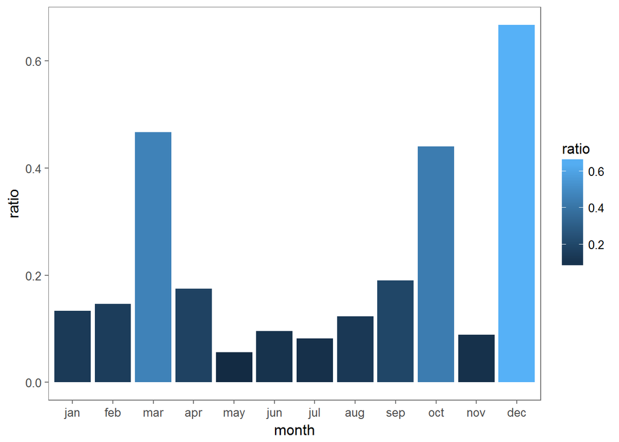

```r
month <- vector()
month.ratio <- vector()

for(i in levels(test.dataset[,"month"])){

    temp.month.rows <- which(test.dataset[,"month"] == i)
    temp.month.dataset <- test.dataset[temp.month.rows,]

    temp.deposit <- rep(0, nrow(temp.month.dataset))
    temp.deposit[temp.month.dataset[,"y"] == "yes"] <- 1

    temp.ratio <- sum(temp.deposit)/length(temp.deposit)

    month <- c(month, i)
    month.ratio <- c(month.ratio, temp.ratio)
}

month.order <- c(5,4,8,1,9,7,6,2,12,11,10,3)
ordered.month <- month[month.order]
ordered.month.ratio <- month.ratio[month.order]

month.data.frame <- as.data.frame(cbind(ordered.month, ordered.month.ratio))
colnames(month.data.frame) <- c("month", "ratio")

month.data.frame$ratio <- as.numeric(as.character(month.data.frame$ratio))
month.data.frame$month <- factor(month.data.frame$month, levels = month.data.frame$month)

month.plot <- ggplot(month.data.frame, aes(x = month, y = ratio, fill = ratio)) + geom_bar(stat='identity') + theme_few()
print(month.plot)
```

The best months for a curtomer to suscribe a term deposit are december, march and october.

> Age influence

We will try to determinate the age when customer are most likely to subscribed a term deposit. We will separate the age in 4 categories : 19 - 29 ans 30 - 39 ans 40 - 59 ans > 60 ans

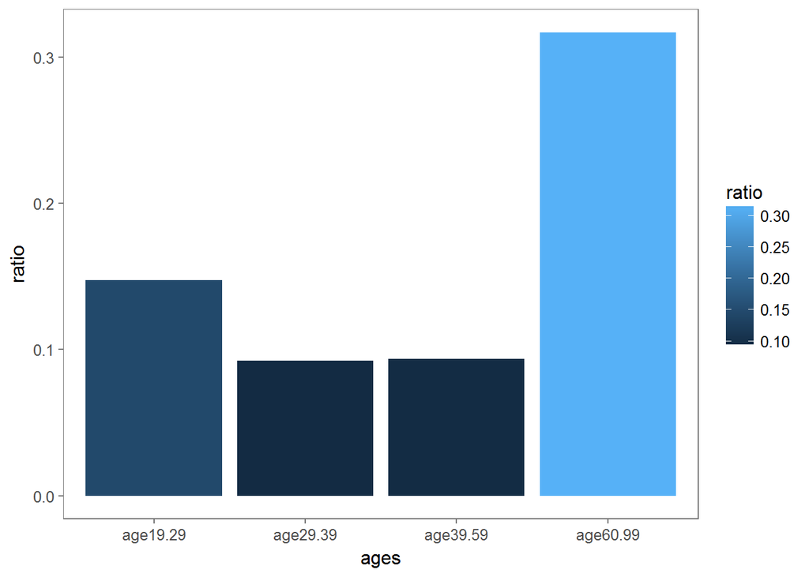

```r
age29.rows <- which(test.dataset[,"age"] <= 29)
age29.dataset <- test.dataset[age29.rows,]
age29.deposit <- rep(0, nrow(age29.dataset))
age29.deposit[age29.dataset[,"y"] == "yes"] <- 1
age29.ratio <- sum(age29.deposit)/length(age29.deposit)

age39.rows <- which(test.dataset[,"age"] <= 39 & test.dataset[,"age"] > 29)
age39.dataset <- test.dataset[age39.rows,]
age39.deposit <- rep(0, nrow(age39.dataset))
age39.deposit[age39.dataset[,"y"] == "yes"] <- 1
age39.ratio <- sum(age39.deposit)/length(age39.deposit)

age59.rows <- which(test.dataset[,"age"] <= 59 & test.dataset[,"age"] > 39)
age59.dataset <- test.dataset[age59.rows,]
age59.deposit <- rep(0, nrow(age59.dataset))
age59.deposit[age59.dataset[,"y"] == "yes"] <- 1
age59.ratio <- sum(age59.deposit)/length(age59.deposit)

age60.rows <- which(test.dataset[,"age"] > 59)
age60.dataset <- test.dataset[age60.rows,]
age60.deposit <- rep(0, nrow(age60.dataset))
age60.deposit[age60.dataset[,"y"] == "yes"] <- 1
age60.ratio <- sum(age60.deposit)/length(age60.deposit)


ages <- c("age19.29", "age29.39", "age39.59", "age60.99")
ratio <- c(age29.ratio, age39.ratio, age59.ratio, age60.ratio)

age.data.frame <- as.data.frame(cbind(ages, ratio))
age.data.frame$ratio <- as.numeric(as.character(age.data.frame$ratio))

age.plot <- ggplot(age.data.frame, aes(x = ages, y = ratio, fill = ratio)) + geom_bar(stat='identity') + theme_few()
print(age.plot)
```

We can see that the main categories are the older customer, and then the younger.

> Job influence

We will try to determinate the jobs that are the most likely to subscribed a term deposit.

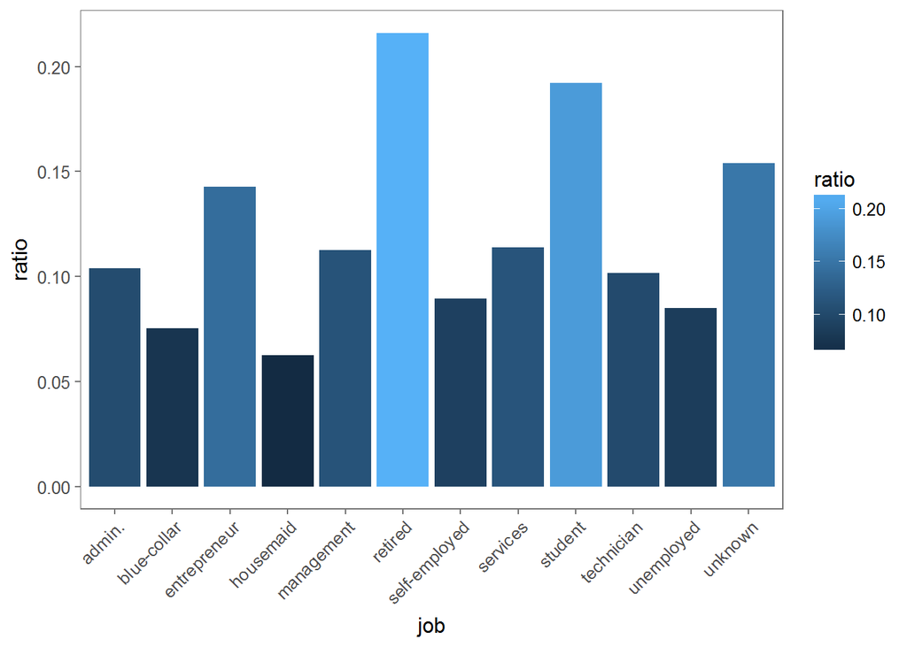

```r
job <- vector()
ratio <- vector()

for(i in levels(test.dataset[,"job"])){

    temp.job.rows <- which(test.dataset[,"job"] == i)
    temp.job.dataset <- test.dataset[temp.job.rows,]

    temp.deposit <- rep(0, nrow(temp.job.dataset))
    temp.deposit[temp.job.dataset[,"y"] == "yes"] <- 1

    temp.ratio <- sum(temp.deposit)/length(temp.deposit)

    job <- c(job, i)
    ratio <- c(ratio, temp.ratio)
}

job.data.frame <- as.data.frame(cbind(job, ratio))
job.data.frame$ratio <- as.numeric(as.character(job.data.frame$ratio))

job.plot <- ggplot(job.data.frame, aes(x = job, y = ratio, fill = ratio)) + geom_bar(stat='identity') + theme_few() + theme(axis.text.x=element_text(angle=45,hjust=1,vjust=1))
print(job.plot)
```

## Logistic Regression

```r
glm.fit=glm(y~ ., data=train.baseline, family=binomial)
summary(glm.fit)
```

```
##
## Call:
## glm(formula = y ~ ., family = binomial, data = train.baseline)
##
## Deviance Residuals:
##     Min       1Q   Median       3Q      Max
## -2.8796  -0.3894  -0.2535  -0.1634   2.8672
##
## Coefficients:
##                      Estimate Std. Error z value Pr(>|z|)
## (Intercept)        -2.257e+00  1.043e+00  -2.164  0.03048 *
## age                -7.787e-03  1.261e-02  -0.617  0.53700
## jobblue-collar     -2.666e-01  3.980e-01  -0.670  0.50298
## jobentrepreneur    -1.133e+00  7.536e-01  -1.504  0.13268
## jobhousemaid        6.701e-01  6.269e-01   1.069  0.28505
## jobmanagement       9.609e-02  4.075e-01   0.236  0.81359
## jobretired          7.213e-01  5.305e-01   1.360  0.17391
## jobself-employed    4.329e-02  5.711e-01   0.076  0.93958
## jobservices        -2.939e-01  4.899e-01  -0.600  0.54861
## jobstudent          1.317e+00  5.753e-01   2.289  0.02211 *
## jobtechnician      -5.340e-01  4.002e-01  -1.334  0.18210
## jobunemployed      -4.312e-02  6.579e-01  -0.066  0.94774
## jobunknown          2.489e-01  1.155e+00   0.216  0.82931
## maritalmarried     -3.465e-01  3.111e-01  -1.114  0.26542
## maritalsingle      -1.326e-01  3.683e-01  -0.360  0.71878
## educationsecondary  4.184e-01  3.566e-01   1.173  0.24060
## educationtertiary   5.635e-01  4.079e-01   1.381  0.16718
## educationunknown   -5.768e-01  6.763e-01  -0.853  0.39376
## defaultyes         -2.192e+00  1.881e+00  -1.165  0.24385
## balance            -5.466e-06  3.404e-05  -0.161  0.87244
## housingyes         -6.359e-01  2.410e-01  -2.639  0.00832 **
## loanyes            -2.201e-01  3.102e-01  -0.710  0.47801
## day                 3.255e-03  1.383e-02   0.235  0.81393
## monthaug            2.596e-01  4.395e-01   0.591  0.55469
## monthdec            4.460e-01  1.062e+00   0.420  0.67450
## monthfeb            5.071e-02  5.347e-01   0.095  0.92444
## monthjan           -1.448e+00  8.594e-01  -1.685  0.09190 .
## monthjul           -4.827e-01  4.536e-01  -1.064  0.28718
## monthjun            1.006e-01  4.537e-01   0.222  0.82449
## monthmar            9.236e-01  6.889e-01   1.341  0.18000
## monthmay           -7.010e-01  3.797e-01  -1.846  0.06485 .
## monthnov           -7.202e-01  4.837e-01  -1.489  0.13650
## monthoct            1.217e+00  5.467e-01   2.227  0.02597 *
## monthsep            5.286e-01  6.914e-01   0.764  0.44460
## duration            4.046e-03  3.408e-04  11.872  < 2e-16 ***
## campaign           -1.425e-01  6.267e-02  -2.274  0.02294 *
## pdays               1.176e-03  1.755e-03   0.670  0.50266
## previous           -5.177e-02  6.040e-02  -0.857  0.39140
## poutcomeother       3.595e-01  4.610e-01   0.780  0.43553
## poutcomesuccess     2.379e+00  4.933e-01   4.824 1.41e-06 ***
## poutcomeunknown    -4.001e-01  5.482e-01  -0.730  0.46551
## ---
## Signif. codes:  0 '***' 0.001 '**' 0.01 '*' 0.05 '.' 0.1 ' ' 1
##
## (Dispersion parameter for binomial family taken to be 1)
##
##     Null deviance: 1088.21  on 1513  degrees of freedom
## Residual deviance:  739.38  on 1473  degrees of freedom
## AIC: 821.38
##
## Number of Fisher Scoring iterations: 6
```

```r
glm.probs <- predict(glm.fit, test.dataset, type="response")

glm.pred <- rep("No", nrow(test.dataset))
glm.pred[glm.probs > 0.5]="Yes"

logistical.confusion.matrix <- table(glm.pred, test.dataset[,"y"])
print(logistical.confusion.matrix)
```

```
##
## glm.pred   no  yes
##      No  1297  104
##      Yes   34   57
```

```r
logistical.classifier.accuracy <- sum(diag(logistical.confusion.matrix)) / sum(logistical.confusion.matrix)
print(logistical.classifier.accuracy)
```

```
## [1] 0.9075067
```

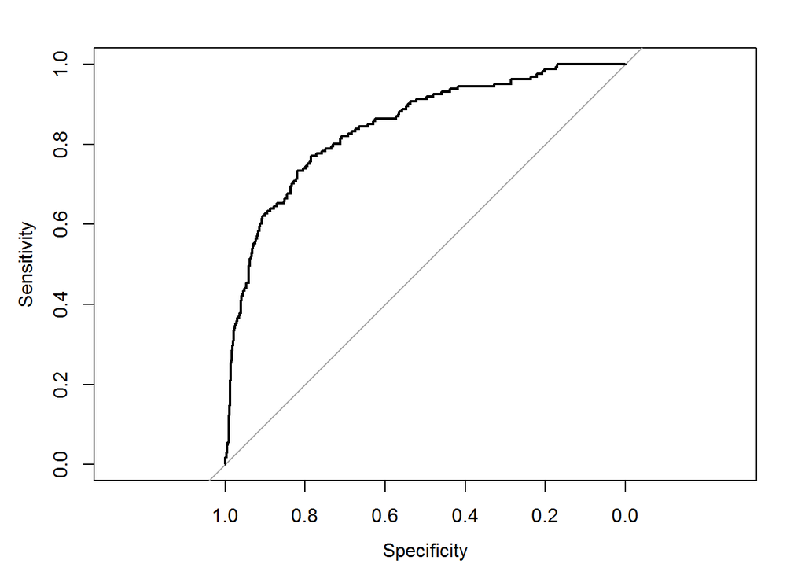

```
##
## Call:
## roc.formula(formula = y ~ glm.probs, data = test.dataset)
##
## Data: glm.probs in 1331 controls (y no) < 161 cases (y yes).
## Area under the curve: 0.845
```

```r
logistical.roc <- roc(y ~ glm.probs, data = test.dataset)
plot(logistical.roc)
```

```r
logistical.auc <- auc(y ~ glm.probs, data = test.dataset)
print(logistical.auc)
```

```
## Area under the curve: 0.845
```

## Random Forest

```r
rf.fit = randomForest(y~., data = train.baseline, mtry = 4, ntree=1000)
print(rf.fit)
```

```
##
## Call:
##  randomForest(formula = y ~ ., data = train.baseline, mtry = 4,      ntree = 1000)
##                Type of random forest: classification
##                      Number of trees: 1000
## No. of variables tried at each split: 4
##
##         OOB estimate of  error rate: 11.76%
## Confusion matrix:
##       no yes class.error
## no  1289  49  0.03662182
## yes  129  47  0.73295455
```

```r
rf.pred = predict(rf.fit, test.dataset, type = "response")

rf.confusion.matrix <- table(rf.pred, test.dataset[,"y"])
print(rf.confusion.matrix)
```

```
##
## rf.pred   no  yes
##     no  1288  103
##     yes   43   58
```

```r
rf.classifier.accuracy <- sum(diag(rf.confusion.matrix)) / sum(rf.confusion.matrix)
print(rf.classifier.accuracy)
```

```
## [1] 0.9021448
```

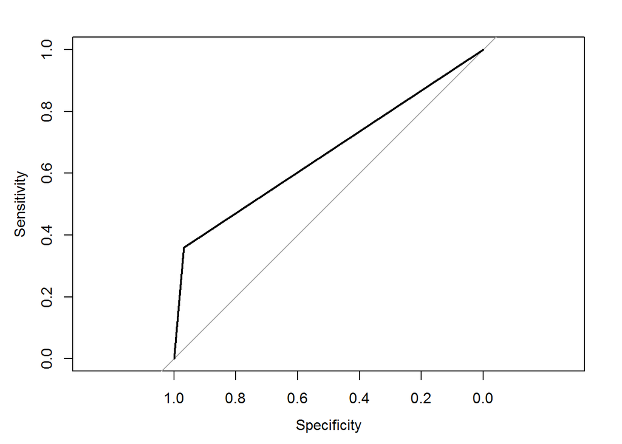

```
##
## Call:
## roc.default(response = roc.test.dataset, predictor = roc.rf.pred)
##
## Data: roc.rf.pred in 1331 controls (roc.test.dataset 0) < 161 cases (roc.test.dataset 1).
## Area under the curve: 0.664
```

```r
roc.rf.pred <- rep(0, nrow(test.dataset))
roc.rf.pred[rf.pred == "yes"] <- 1

roc.test.dataset <- rep(0, nrow(test.dataset))
roc.test.dataset[test.dataset[,"y"] == "yes"] <- 1

rf.roc <- roc(roc.test.dataset, roc.rf.pred)
plot(rf.roc)
```

```r
rf.auc <- auc(roc.test.dataset, roc.rf.pred)
print(rf.auc)
```

```
## Area under the curve: 0.664
```

> Get variable importance on RF

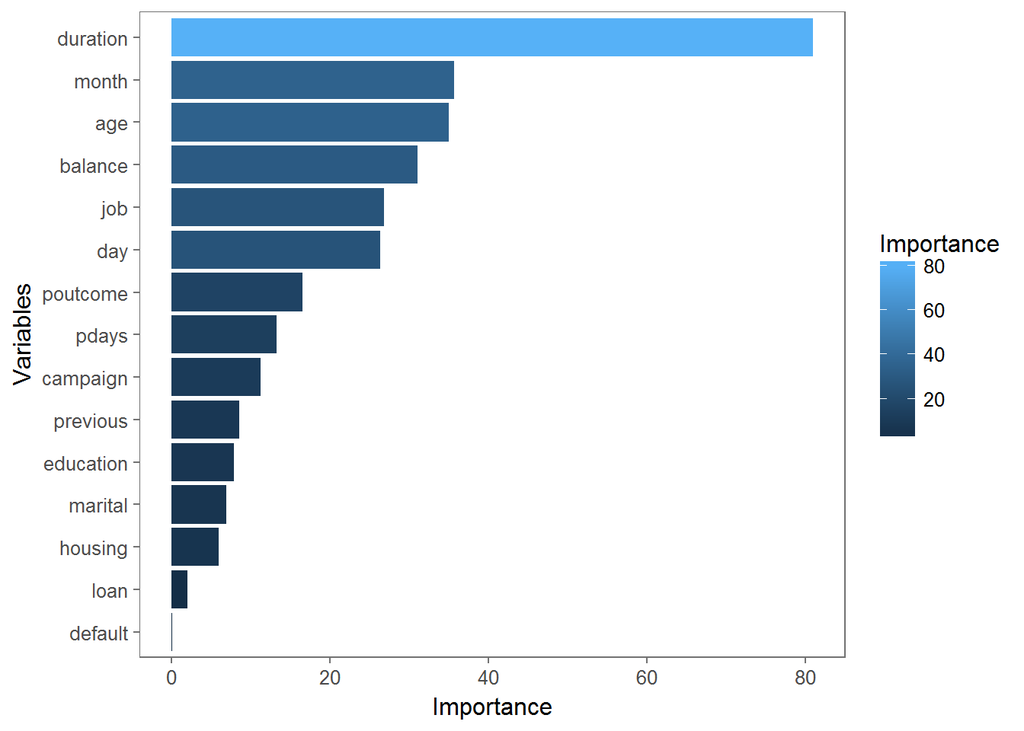

```r
rf.importance <- importance(rf.fit)
varImportance <- data.frame(Variables = row.names(rf.importance),
                            Importance = round(rf.importance[ ,'MeanDecreaseGini'],2))

# Create a rank variable based on importance
rankImportance <- varImportance %>%
  mutate(Rank = paste0('#',dense_rank(desc(Importance))))

# Use ggplot2 to visualize the relative importance of variables
ggplot(rankImportance, aes(x = reorder(Variables, Importance),
    y = Importance, fill = Importance)) +
  geom_bar(stat='identity') +
  labs(x = 'Variables') +
  coord_flip() +
  theme_few()
```

## Classification tree

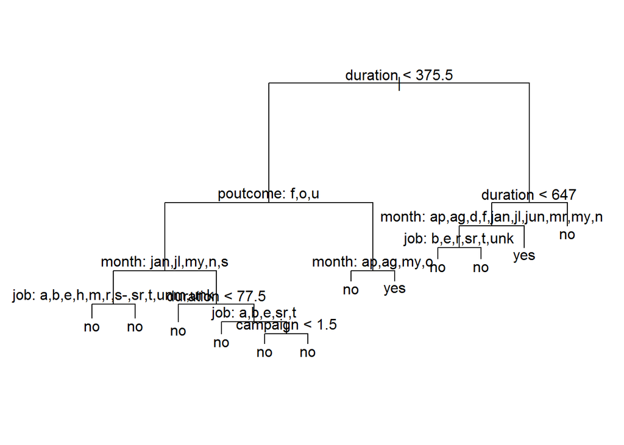

```r
# fitting
tr.fit = tree(y~., train.baseline)

# plotting tree
plot(tr.fit)
text(tr.fit, pretty = 1)
```

```r
# making predictions
tr.pred = as.data.frame(predict(tr.fit, test.dataset, type = "vector"))

# disctretizing probabilities
tr.values.pred <- rep("no", nrow(test.dataset))
tr.values.pred[tr.pred$yes > 0.5]="yes"

# making confusion matrix
tr.confusion.matrix <- table(tr.values.pred, test.dataset[,"y"])
print(tr.confusion.matrix)
```

```
##
## tr.values.pred   no  yes
##            no  1322  148
##            yes    9   13
```

```r
# calculating classifier accuracy
tr.classifier.accuracy <- sum(diag(tr.confusion.matrix)) / sum(tr.confusion.matrix)
print(tr.classifier.accuracy)
```

```
## [1] 0.8947721
```

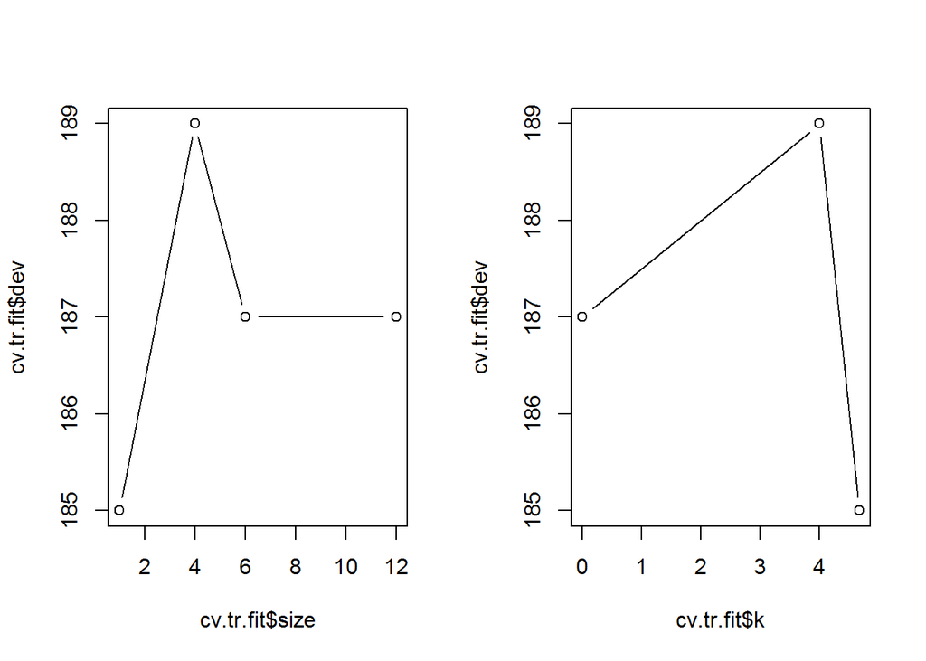

```r
# evaluating miss-classification rate
set.seed(3)
cv.tr.fit=cv.tree(tr.fit,FUN=prune.misclass)
par(mfrow=c(1,2))
plot(cv.tr.fit$size,cv.tr.fit$dev,type="b")
plot(cv.tr.fit$k,cv.tr.fit$dev,type="b")
```

```r
# getting best value
prune.tr.fit=prune.misclass(tr.fit,best=2)
plot(prune.tr.fit)
text(prune.tr.fit,pretty = 1)

# making predictions
tr.pred = as.data.frame(predict(prune.tr.fit, test.dataset, type = "vector"))

# disctretizing probabilities
tr.values.pred <- rep("no", nrow(test.dataset))
tr.values.pred[tr.pred$yes > 0.5]="yes"

# making confusion matrix
tr.confusion.matrix <- table(tr.values.pred, test.dataset[,"y"])
print(tr.confusion.matrix)
```

```
##
## tr.values.pred   no  yes
##            no  1326  152
##            yes    5    9
```

```r
# calculating classifier accuracy
tr.classifier.accuracy <- sum(diag(tr.confusion.matrix)) / sum(tr.confusion.matrix)
print(tr.classifier.accuracy)
```

```
## [1] 0.8947721
```

[figure not shown]

## Na?ve Bayes

```r
nb.fit=naiveBayes(y~ ., data=train.baseline)
summary(nb.fit)
```

```
##         Length Class  Mode
## apriori  2     table  numeric
## tables  15     -none- list
## levels   2     -none- character
## call     4     -none- call
```

```r
nb.probs <- predict(nb.fit, test.dataset, type="raw")[,2]

nb.pred <- predict(nb.fit, test.dataset, type="class")

nb.confusion.matrix <- table(nb.pred, test.dataset[,"y"])
print(nb.confusion.matrix)
```

```
##
## nb.pred   no  yes
##     no  1205   78
##     yes  126   83
```

```r
nb.classifier.accuracy <- sum(diag(nb.confusion.matrix)) / sum(nb.confusion.matrix)
print(nb.classifier.accuracy)
```

```
## [1] 0.8632708
```

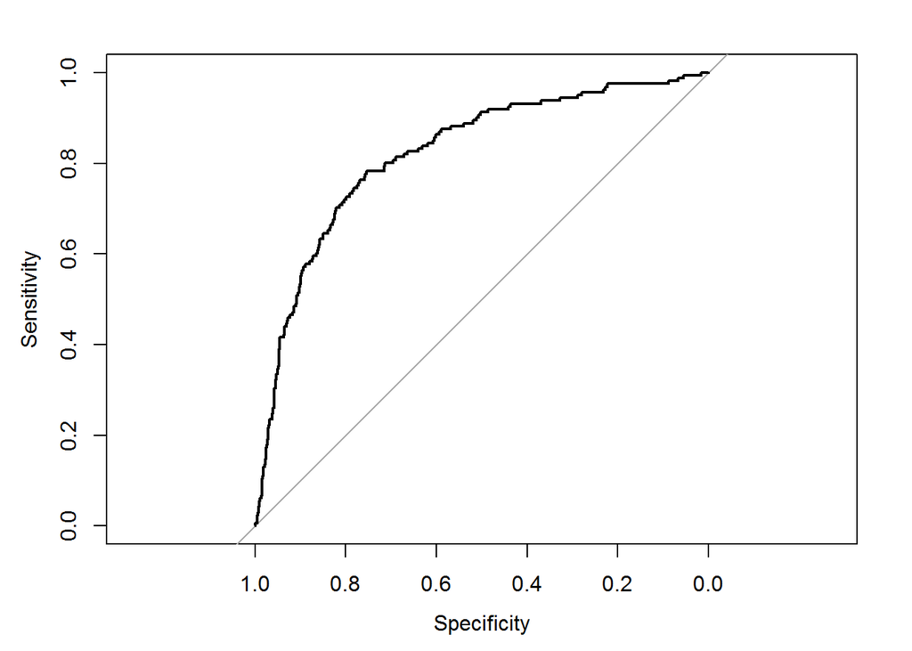

```
##
## Call:
## roc.formula(formula = y ~ nb.probs, data = test.dataset)
##
## Data: nb.probs in 1331 controls (y no) < 161 cases (y yes).
## Area under the curve: 0.8211
```

```r
nb.roc <- roc(y ~ nb.probs, data = test.dataset)
plot(nb.roc)
```

```r
nb.auc <- auc(y ~ nb.probs, data = test.dataset)
print(nb.auc)
```

```
## Area under the curve: 0.8211
```

## Stacking

> Predict using train stacking dataset with previous algorithms

```r
rf.stacking.train.probs <- predict(rf.fit, train.stacking, type="prob")[,2]
glm.stacking.train.probs <- predict(glm.fit, train.stacking, type="response")
nb.stacking.train.probs <- predict(nb.fit, train.stacking, type="raw")[,2]
tr.stacking.train.probs <- predict(tr.fit, train.stacking, type = "vector")[,2]
```

> Predict using test dataset with previous algorithms

```r
rf.stacking.test.probs <- predict(rf.fit, test.dataset, type="prob")[,2]
glm.stacking.test.probs <- predict(glm.fit, test.dataset, type="response")
nb.stacking.test.probs <- predict(nb.fit, test.dataset, type="raw")[,2]
tr.stacking.test.probs <- predict(tr.fit, test.dataset, type = "vector")[,2]
```

> Gather data

```r
stacking.data.train <- data.frame("Random Forest"=rf.stacking.train.probs, "Logistic Regression" = glm.stacking.train.probs, "Na?ve Bayes"=nb.stacking.train.probs, "Classification tree"=tr.stacking.train.probs,"y"=train.stacking[,"y"])

stacking.data.test <- data.frame("Random Forest"=rf.stacking.test.probs, "Logistic Regression" = glm.stacking.test.probs, "Na?ve Bayes"=nb.stacking.test.probs, "Classification tree"=tr.stacking.test.probs,"y"=test.dataset[,"y"])
```

> Build logistic regression model

```r
glm.stacking.fit=glm(y~ ., data=stacking.data.train, family=binomial)
summary(glm.stacking.fit)
```

```
##
## Call:
## glm(formula = y ~ ., family = binomial, data = stacking.data.train)
##
## Deviance Residuals:
##     Min       1Q   Median       3Q      Max
## -2.2730  -0.3160  -0.2520  -0.2336   2.6976
##
## Coefficients:
##                     Estimate Std. Error z value Pr(>|z|)
## (Intercept)          -3.6511     0.1643 -22.226  < 2e-16 ***
## Random.Forest         7.0300     0.9412   7.469 8.07e-14 ***
## Logistic.Regression   0.5021     0.7547   0.665   0.5059
## Na.ve.Bayes          -0.2859     0.4330  -0.660   0.5091
## Classification.tree   1.1297     0.6483   1.743   0.0814 .
## ---
## Signif. codes:  0 '***' 0.001 '**' 0.01 '*' 0.05 '.' 0.1 ' ' 1
##
## (Dispersion parameter for binomial family taken to be 1)
##
##     Null deviance: 1120.52  on 1514  degrees of freedom
## Residual deviance:  748.41  on 1510  degrees of freedom
## AIC: 758.41
##
## Number of Fisher Scoring iterations: 6
```

> Build Na?ve Bayes model

```r
nb.stacking.fit=naiveBayes(y~ ., data=stacking.data.train)
summary(nb.stacking.fit)
```

```
##         Length Class  Mode
## apriori 2      table  numeric
## tables  4      -none- list
## levels  2      -none- character
## call    4      -none- call
```

> Build Random Forest

```r
rf.stacking.fit=randomForest(y~ ., data=stacking.data.train, mtry = 2, ntree=1000)
print(rf.stacking.fit)
```

```
##
## Call:
##  randomForest(formula = y ~ ., data = stacking.data.train, mtry = 2,      ntree = 1000)
##                Type of random forest: classification
##                      Number of trees: 1000
## No. of variables tried at each split: 2
##
##         OOB estimate of  error rate: 10.89%
## Confusion matrix:
##       no yes class.error
## no  1280  51  0.03831705
## yes  114  70  0.61956522
```

> Predict on test for Random Forest

```r
rf.stacking.pred = predict(rf.stacking.fit, stacking.data.test, type = "response")

rf.stacking.confusion.matrix <- table(rf.stacking.pred, test.dataset[,"y"])
print(rf.stacking.confusion.matrix)
```

```
##
## rf.stacking.pred   no  yes
##              no  1270   92
##              yes   61   69
```

```r
rf.stacking.classifier.accuracy <- sum(diag(rf.stacking.confusion.matrix)) / sum(rf.stacking.confusion.matrix)
print(rf.stacking.classifier.accuracy)
```

```
## [1] 0.8974531
```

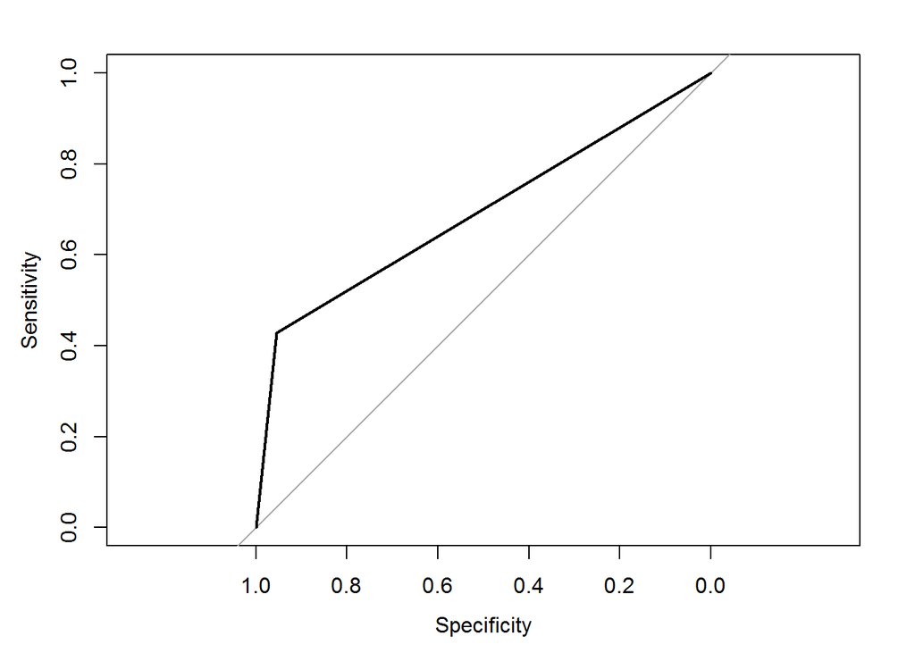

```
##
## Call:
## roc.default(response = roc.stacking.test.dataset, predictor = roc.rf.stacking.pred)
##
## Data: roc.rf.stacking.pred in 1331 controls (roc.stacking.test.dataset 0) < 161 cases (roc.stacking.test.dataset 1).
## Area under the curve: 0.6914
```

```r
roc.rf.stacking.pred <- rep(0, nrow(test.dataset))
roc.rf.stacking.pred[rf.stacking.pred == "yes"] <- 1

roc.stacking.test.dataset <- rep(0, nrow(test.dataset))
roc.stacking.test.dataset[test.dataset[,"y"] == "yes"] <- 1

rf.stacking.roc <- roc(roc.stacking.test.dataset, roc.rf.stacking.pred)
plot(rf.stacking.roc)
```

```r
rf.stacking.auc <- auc(roc.stacking.test.dataset, roc.rf.stacking.pred)
print(rf.stacking.auc)
```

```
## Area under the curve: 0.6914
```

> Predict on test for Na?ve Bayes

```r
nb.stacking.probs <- predict(nb.stacking.fit, newdata=stacking.data.test, type="raw")[,2]

nb.stacking.pred <- predict(nb.stacking.fit, newdata=stacking.data.test, type="class")

nb.stacking.confusion.matrix <- table(nb.stacking.pred, test.dataset[,"y"])
print(nb.stacking.confusion.matrix)
```

```
##
## nb.stacking.pred   no  yes
##              no  1210   60
##              yes  121  101
```

```r
nb.stacking.classifier.accuracy <- sum(diag(nb.stacking.confusion.matrix)) / sum(nb.stacking.confusion.matrix)
print(nb.stacking.classifier.accuracy)
```

```
## [1] 0.8786863
```

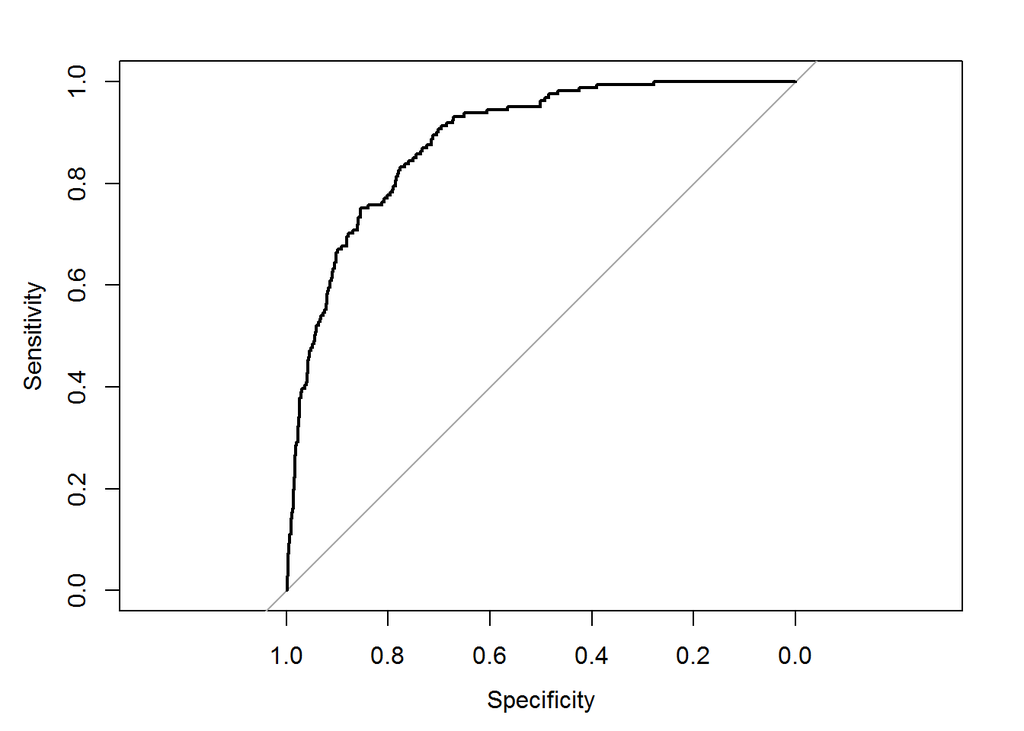

```
##
## Call:
## roc.formula(formula = y ~ nb.stacking.probs, data = test.dataset)
##
## Data: nb.stacking.probs in 1331 controls (y no) < 161 cases (y yes).
## Area under the curve: 0.8857
```

```r
nb.stacking.roc <- roc(y ~ nb.stacking.probs, data = test.dataset)
plot(nb.stacking.roc)
```

```r
nb.stacking.auc <- auc(y ~ nb.stacking.probs, data = test.dataset)
print(nb.stacking.auc)
```

```
## Area under the curve: 0.8857
```

> Predict on test for logistic regression

```r
glm.stacking.probs <- predict(glm.stacking.fit, newdata=stacking.data.test, type="response")

glm.stacking.pred <- rep("No", nrow(test.dataset))
glm.stacking.pred[glm.stacking.probs > 0.5]="Yes"

logistical.stacking.confusion.matrix <- table(glm.stacking.pred, test.dataset[,"y"])
print(logistical.stacking.confusion.matrix)
```

```
##
## glm.stacking.pred   no  yes
##               No  1274   97
##               Yes   57   64
```

```r
logistical.stacking.classifier.accuracy <- sum(diag(logistical.stacking.confusion.matrix)) / sum(logistical.stacking.confusion.matrix)
print(logistical.stacking.classifier.accuracy)
```

```
## [1] 0.8967828
```

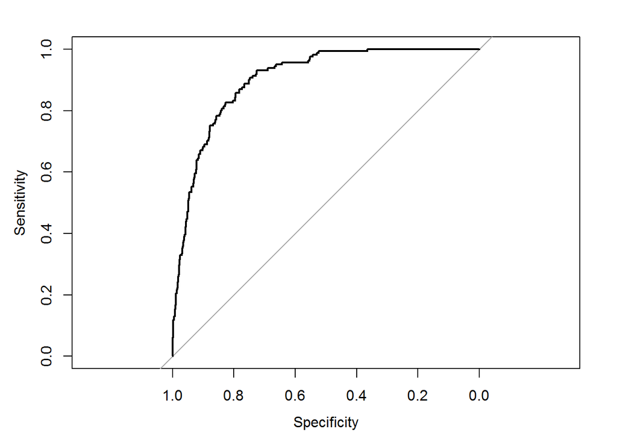

```
##
## Call:
## roc.formula(formula = y ~ glm.stacking.probs, data = test.dataset)
##
## Data: glm.stacking.probs in 1331 controls (y no) < 161 cases (y yes).
## Area under the curve: 0.9028
```

```r
logistical.stacking.roc <- roc(y ~ glm.stacking.probs, data = test.dataset)
plot(logistical.stacking.roc)
```

```r
logistical.stacking.auc <- auc(y ~ glm.stacking.probs, data = test.dataset)
print(logistical.stacking.auc)
```

```
## Area under the curve: 0.9028
```

## Generate other seed to test accuracy on other train/test data

```r
seed.probabilities <- NULL

for (i in 1:10)
{
    set.seed(i)

    test <- sample(nrow(dataset), round(nrow(dataset) * 0.33))
    test.dataset <- dataset[test,]
    train.dataset <- dataset[-test,]

    train <- sample(nrow(train.dataset), round(nrow(train.dataset) * 0.50))
    train.baseline <- train.dataset[train,]
    train.stacking <- train.dataset[-train,]

    glm.fit=glm(y~ ., data=train.baseline, family=binomial)

    glm.probs <- predict(glm.fit, test.dataset, type="response")

    glm.pred <- rep("No", nrow(test.dataset))
    glm.pred[glm.probs > 0.5]="Yes"

    logistical.confusion.matrix <- table(glm.pred, test.dataset[,"y"])

    logistical.classifier.accuracy <- sum(diag(logistical.confusion.matrix)) / sum(logistical.confusion.matrix)

    rf.fit = randomForest(y~., data = train.baseline, mtry = 4, ntree=1000)

    rf.pred = predict(rf.fit, test.dataset, type = "response")

    rf.confusion.matrix <- table(rf.pred, test.dataset[,"y"])

    rf.classifier.accuracy <- sum(diag(rf.confusion.matrix)) / sum(rf.confusion.matrix)

    # fitting
    tr.fit = tree(y~., train.baseline)

    # making predictions
    tr.pred = as.data.frame(predict(tr.fit, test.dataset, type = "vector"))

    # disctretizing probabilities
    tr.values.pred <- rep("no", nrow(test.dataset))
    tr.values.pred[tr.pred$yes > 0.5]="yes"

    # making confusion matrix
    tr.confusion.matrix <- table(tr.values.pred, test.dataset[,"y"])

    # calculating classifier accuracy
    tr.classifier.accuracy <- sum(diag(tr.confusion.matrix)) / sum(tr.confusion.matrix)

    # evaluating miss-classification rate
    set.seed(i)
    cv.tr.fit=cv.tree(tr.fit,FUN=prune.misclass)

    # getting best value
    prune.tr.fit=prune.misclass(tr.fit,best=2)

    # making predictions
    tr.pred = as.data.frame(predict(prune.tr.fit, test.dataset, type = "vector"))

    # disctretizing probabilities
    tr.values.pred <- rep("no", nrow(test.dataset))
    tr.values.pred[tr.pred$yes > 0.5]="yes"

    # making confusion matrix
    tr.confusion.matrix <- table(tr.values.pred, test.dataset[,"y"])

    # calculating classifier accuracy
    tr.classifier.accuracy <- sum(diag(tr.confusion.matrix)) / sum(tr.confusion.matrix)

    nb.fit=naiveBayes(y~ ., data=train.baseline)

    nb.probs <- predict(nb.fit, test.dataset, type="raw")[,2]

    nb.pred <- predict(nb.fit, test.dataset, type="class")

    nb.confusion.matrix <- table(nb.pred, test.dataset[,"y"])

    nb.classifier.accuracy <- sum(diag(nb.confusion.matrix)) / sum(nb.confusion.matrix)

    seed.probabilities <- rbind(seed.probabilities, c(rf.classifier.accuracy, nb.classifier.accuracy, tr.classifier.accuracy, logistical.classifier.accuracy))
}

rf.seed.deviation <- sd(seed.probabilities[,1])
nb.seed.deviation <- sd(seed.probabilities[,2])
tr.seed.deviation <- sd(seed.probabilities[,3])
logistical.seed.deviation <- sd(seed.probabilities[,4])
```

| Algorithm name | Standard deviation |
| --- | --- |
| Random Forest | 0.0060135 |
| Naive Bayes | 0.0090036 |
| Tree Classification | 0.0061201 |
| Logistical regression | 0.0058839 |

We can see on the table that all algorithms have low standard deviation which is good.

## Simulation of a marketing campaign

We modify the test dataset to create “favorable customers”" according the section *Data Analysis* so we set the age of customer to a random value between 60 and 80 years, the job to retired and the month to december. The goal is to see if a targeted advertising campaign could be usefull for the bank.

```r
dataset.favorable.cutomers <- test.dataset

for( i in 1:nrow(dataset.favorable.cutomers)) {
    dataset.favorable.cutomers[i, "age"] <- sample(60:80, 1)
    dataset.favorable.cutomers[i, "job"] <- "retired"
    dataset.favorable.cutomers[i, "month"] <- "dec"
}
```

Now we have our data frame. Let’s test the results with the previous random forest model.

```r
rf.fit = randomForest(y~., data = train.baseline, mtry = 4, ntree=1000)
print(rf.fit)
```

```
##
## Call:
##  randomForest(formula = y ~ ., data = train.baseline, mtry = 4,      ntree = 1000)
##                Type of random forest: classification
##                      Number of trees: 1000
## No. of variables tried at each split: 4
##
##         OOB estimate of  error rate: 11.69%
## Confusion matrix:
##       no yes class.error
## no  1268  60  0.04518072
## yes  117  69  0.62903226
```

```r
tc.rf.pred = predict(rf.fit, dataset.favorable.cutomers, type = "response")
test.result <- rep(0, nrow(test.dataset))
test.result[test.dataset$y=="yes"] <- 1
```

Let’s calculate the sum of the total number of customer who subscribe a term deposit in the original test dataset.

```r
test.nb.success <- sum(test.result)
print(test.nb.success)
```

```
## [1] 159
```

We can have the ratio of success.

```r
test.success.ratio <- sum(test.result)/length(test.result)
print(test.success.ratio)
```

```
## [1] 0.1065684
```

Now, let’s see the number of customer who subscribe a term deposit and the success ratio we get with the modified test dataset.

```r
tc.result <- rep(0, length(tc.rf.pred))
tc.result[tc.rf.pred=="yes"] <- 1

tc.nb.success <- sum(tc.result)
print(tc.nb.success)
```

```
## [1] 619
```

```r
tc.success.ratio <- sum(tc.result)/length(tc.result)
print(tc.success.ratio)
```

```
## [1] 0.4148794
```

So here are the results :

| – | original dataset | dataset modified |
| --- | --- | --- |
| Number of subscription | 159 | 619 |
| Ratio | 0.1065684 | 0.4148794 |

We can see that with a targeted marketing campaign, we can multiply our chance of success by 4.